# Project : Data analysis with Gapminder datasets

- Overview
- Data Wrangling
- Exploratory Data Analysis
- Conclusions

# Overview

This project aimed to analyze different datasets from [Gapminder World](https://www.gapminder.org/data/). Before analysis, data wrangling was done for combining the datasets and removing null values. After the wrangling part, Temporal trends of the datasets were compared with line plots and relationships between datasets were analyzed with scatter plots.

## Datasets

- Income per person (GDP/capita, PPP$ inflation-adjusted)
- CO2 emissions (tonnes per person)
- Life expectancy
- Child mortality

## Research Questions

The dataset will be analyzed with these research questions.

- How have indicators changed in global scale?
- How were the other indicators correlated with personal income level?

```python
# import libraries
import pandas as pd
import numpy as np
import matplotlib.pyplot as plt
import seaborn as sns

%matplotlib inline
```

```python
# load datasets
df_income = pd.read_csv('data/income_per_person_gdppercapita_ppp_inflation_adjusted.csv')
df_co2 = pd.read_csv('data/co2_emissions_tonnes_per_person.csv')
df_life = pd.read_csv('data/life_expectancy_years.csv')
df_school = pd.read_csv('data/primary_completion_rate_total_percent_of_relevant_age_group.csv')
df_child = pd.read_csv('data/child_mortality_0_5_year_olds_dying_per_1000_born.csv')
```

# Data Wrangling

To prepare the analysis part, the datasets need to be reshaped, joined, cleaned. Here, I will reshape the dataset first, and then join the datasets. After that, the null values will be removed.

## Modify datasets

In this part, I will modify (reshape) and join the dataset, so that every attributes in a same dataframe. After joining and modifying the datsets, columns of the processed dataset might look like: {Country, Year, Indicator 1 Value, Indicator 2 Value, … }

```python
df_income.head()
```

|  | country | 1800 | 1801 | 1802 | 1803 | 1804 | 1805 | 1806 | 1807 | 1808 | ... | 2031 | 2032 | 2033 | 2034 | 2035 | 2036 | 2037 | 2038 | 2039 | 2040 |
| --- | --- | --- | --- | --- | --- | --- | --- | --- | --- | --- | --- | --- | --- | --- | --- | --- | --- | --- | --- | --- | --- |
| 0 | Afghanistan | 603 | 603 | 603 | 603 | 603 | 603 | 603 | 603 | 603 | ... | 2550 | 2600 | 2660 | 2710 | 2770 | 2820 | 2880 | 2940 | 3000 | 3060 |
| 1 | Albania | 667 | 667 | 667 | 667 | 667 | 668 | 668 | 668 | 668 | ... | 19400 | 19800 | 20200 | 20600 | 21000 | 21500 | 21900 | 22300 | 22800 | 23300 |
| 2 | Algeria | 715 | 716 | 717 | 718 | 719 | 720 | 721 | 722 | 723 | ... | 14300 | 14600 | 14900 | 15200 | 15500 | 15800 | 16100 | 16500 | 16800 | 17100 |
| 3 | Andorra | 1200 | 1200 | 1200 | 1200 | 1210 | 1210 | 1210 | 1210 | 1220 | ... | 73600 | 75100 | 76700 | 78300 | 79900 | 81500 | 83100 | 84800 | 86500 | 88300 |
| 4 | Angola | 618 | 620 | 623 | 626 | 628 | 631 | 634 | 637 | 640 | ... | 6110 | 6230 | 6350 | 6480 | 6610 | 6750 | 6880 | 7020 | 7170 | 7310 |

5 rows × 242 columns

```python
df_co2.head()
```

|  | country | 1800 | 1801 | 1802 | 1803 | 1804 | 1805 | 1806 | 1807 | 1808 | ... | 2009 | 2010 | 2011 | 2012 | 2013 | 2014 | 2015 | 2016 | 2017 | 2018 |
| --- | --- | --- | --- | --- | --- | --- | --- | --- | --- | --- | --- | --- | --- | --- | --- | --- | --- | --- | --- | --- | --- |
| 0 | Afghanistan | NaN | NaN | NaN | NaN | NaN | NaN | NaN | NaN | NaN | ... | 0.238 | 0.29 | 0.406 | 0.345 | 0.28 | 0.253 | 0.262 | 0.245 | 0.247 | 0.254 |
| 1 | Albania | NaN | NaN | NaN | NaN | NaN | NaN | NaN | NaN | NaN | ... | 1.470 | 1.56 | 1.790 | 1.690 | 1.69 | 1.900 | 1.600 | 1.570 | 1.610 | 1.590 |
| 2 | Algeria | NaN | NaN | NaN | NaN | NaN | NaN | NaN | NaN | NaN | ... | 3.400 | 3.28 | 3.270 | 3.430 | 3.48 | 3.680 | 3.800 | 3.640 | 3.560 | 3.690 |
| 3 | Andorra | NaN | NaN | NaN | NaN | NaN | NaN | NaN | NaN | NaN | ... | 6.120 | 6.12 | 5.870 | 5.920 | 5.90 | 5.830 | 5.970 | 6.070 | 6.270 | 6.120 |
| 4 | Angola | NaN | NaN | NaN | NaN | NaN | NaN | NaN | NaN | NaN | ... | 1.230 | 1.24 | 1.250 | 1.350 | 1.28 | 1.640 | 1.220 | 1.180 | 1.140 | 1.120 |

5 rows × 220 columns

```python
df_life.head()
```

|  | country | 1800 | 1801 | 1802 | 1803 | 1804 | 1805 | 1806 | 1807 | 1808 | ... | 2091 | 2092 | 2093 | 2094 | 2095 | 2096 | 2097 | 2098 | 2099 | 2100 |
| --- | --- | --- | --- | --- | --- | --- | --- | --- | --- | --- | --- | --- | --- | --- | --- | --- | --- | --- | --- | --- | --- |
| 0 | Afghanistan | 28.2 | 28.2 | 28.2 | 28.2 | 28.2 | 28.2 | 28.1 | 28.1 | 28.1 | ... | 76.5 | 76.6 | 76.7 | 76.9 | 77.0 | 77.1 | 77.3 | 77.4 | 77.5 | 77.7 |
| 1 | Albania | 35.4 | 35.4 | 35.4 | 35.4 | 35.4 | 35.4 | 35.4 | 35.4 | 35.4 | ... | 87.4 | 87.5 | 87.6 | 87.7 | 87.8 | 87.9 | 88.0 | 88.1 | 88.2 | 88.3 |
| 2 | Algeria | 28.8 | 28.8 | 28.8 | 28.8 | 28.8 | 28.8 | 28.8 | 28.8 | 28.8 | ... | 88.3 | 88.4 | 88.5 | 88.6 | 88.7 | 88.8 | 88.9 | 89.0 | 89.1 | 89.2 |
| 3 | Andorra | NaN | NaN | NaN | NaN | NaN | NaN | NaN | NaN | NaN | ... | NaN | NaN | NaN | NaN | NaN | NaN | NaN | NaN | NaN | NaN |
| 4 | Angola | 27.0 | 27.0 | 27.0 | 27.0 | 27.0 | 27.0 | 27.0 | 27.0 | 27.0 | ... | 78.7 | 78.9 | 79.0 | 79.1 | 79.3 | 79.4 | 79.5 | 79.7 | 79.8 | 79.9 |

5 rows × 302 columns

```python
df_school.head()
```

|  | country | 1970 | 1971 | 1972 | 1973 | 1974 | 1975 | 1976 | 1977 | 1978 | ... | 2010 | 2011 | 2012 | 2013 | 2014 | 2015 | 2016 | 2017 | 2018 | 2019 |
| --- | --- | --- | --- | --- | --- | --- | --- | --- | --- | --- | --- | --- | --- | --- | --- | --- | --- | --- | --- | --- | --- |
| 0 | Afghanistan | NaN | NaN | NaN | NaN | 0.167 | NaN | NaN | 0.179 | 0.197 | ... | NaN | NaN | NaN | NaN | NaN | NaN | 0.799 | 0.844 | 0.856 | NaN |
| 1 | Albania | NaN | NaN | NaN | NaN | NaN | NaN | NaN | NaN | NaN | ... | 0.888 | 0.930 | 0.987 | 0.895 | 1.01 | 0.989 | 0.999 | 1.020 | 1.020 | NaN |
| 2 | Algeria | NaN | NaN | 0.416 | 0.436 | 0.459 | 0.515 | 0.577 | 0.609 | 0.635 | ... | 0.956 | 0.976 | 1.020 | 1.060 | 1.08 | 1.060 | 1.060 | 1.060 | 1.050 | NaN |
| 3 | Angola | NaN | NaN | NaN | NaN | NaN | NaN | NaN | NaN | NaN | ... | 0.398 | 0.462 | NaN | NaN | NaN | NaN | NaN | NaN | NaN | NaN |
| 4 | Antigua and Barbuda | NaN | NaN | NaN | NaN | NaN | 0.786 | 0.800 | NaN | NaN | ... | 1.070 | 1.040 | NaN | NaN | 1.11 | 0.926 | NaN | 0.982 | 0.962 | NaN |

5 rows × 51 columns

```python
df_child.head()
```

|  | country | 1800 | 1801 | 1802 | 1803 | 1804 | 1805 | 1806 | 1807 | 1808 | ... | 2091 | 2092 | 2093 | 2094 | 2095 | 2096 | 2097 | 2098 | 2099 | 2100 |
| --- | --- | --- | --- | --- | --- | --- | --- | --- | --- | --- | --- | --- | --- | --- | --- | --- | --- | --- | --- | --- | --- |
| 0 | Afghanistan | 469.0 | 469.0 | 469.0 | 469.0 | 469.0 | 469.0 | 470.0 | 470.0 | 470.0 | ... | 12.60 | 12.40 | 12.20 | 12.00 | 11.80 | 11.60 | 11.50 | 11.30 | 11.10 | 11.10 |
| 1 | Albania | 375.0 | 375.0 | 375.0 | 375.0 | 375.0 | 375.0 | 375.0 | 375.0 | 375.0 | ... | 2.32 | 2.30 | 2.27 | 2.24 | 2.22 | 2.19 | 2.16 | 2.14 | 2.11 | 2.11 |
| 2 | Algeria | 460.0 | 460.0 | 460.0 | 460.0 | 460.0 | 460.0 | 460.0 | 460.0 | 460.0 | ... | 4.28 | 4.20 | 4.14 | 4.07 | 4.00 | 3.94 | 3.88 | 3.82 | 3.76 | 3.76 |
| 3 | Andorra | NaN | NaN | NaN | NaN | NaN | NaN | NaN | NaN | NaN | ... | 0.86 | 0.84 | 0.83 | 0.81 | 0.80 | 0.79 | 0.78 | 0.77 | 0.76 | 0.76 |
| 4 | Angola | 486.0 | 486.0 | 486.0 | 486.0 | 486.0 | 486.0 | 486.0 | 486.0 | 486.0 | ... | 17.70 | 17.50 | 17.30 | 17.10 | 17.00 | 16.80 | 16.60 | 16.40 | 16.30 | 16.30 |

5 rows × 302 columns

```python
def modify_dataframe(df, column_name):
    '''
    This function is for reshaping a dataset.
    After reshaping, the columns in the dataframe will look like {Country, Year, Indicator}
    ------
    Input:
        df (pandas.DataFrame): a dataframe which will be modified
        column_name

    '''
    target_ = df.copy().set_index('country').stack(dropna=False).reset_index()
    target_ = target_.rename(columns={'level_1':'year',
                                      0:column_name
    })
    return target_
```

```python
# modify the income dataframe
df_income = modify_dataframe(df_income,'income_per_person')
df_income.head()
```

|  | country | year | income_per_person |
| --- | --- | --- | --- |
| 0 | Afghanistan | 1800 | 603 |
| 1 | Afghanistan | 1801 | 603 |
| 2 | Afghanistan | 1802 | 603 |
| 3 | Afghanistan | 1803 | 603 |
| 4 | Afghanistan | 1804 | 603 |

```python
# apply same process to other datasets
df_co2 = modify_dataframe(df_co2, 'co2_per_person')
df_life = modify_dataframe(df_life, 'life_expectancy')
df_child = modify_dataframe(df_child, 'child_mortality')
```

```python
# join the datasets
df = df_income.merge(df_co2, on=['country','year'], how='outer')
df = df.merge(df_life, on=['country','year'], how='outer')
df = df.merge(df_child, on=['country','year'], how='outer')
```

## General Properties

```python
df.head()
```

|  | country | year | income_per_person | co2_per_person | life_expectancy | child_mortality |
| --- | --- | --- | --- | --- | --- | --- |
| 0 | Afghanistan | 1800 | 603.0 | NaN | 28.2 | 469.0 |
| 1 | Afghanistan | 1801 | 603.0 | NaN | 28.2 | 469.0 |
| 2 | Afghanistan | 1802 | 603.0 | NaN | 28.2 | 469.0 |
| 3 | Afghanistan | 1803 | 603.0 | NaN | 28.2 | 469.0 |
| 4 | Afghanistan | 1804 | 603.0 | NaN | 28.2 | 469.0 |

```python
df.shape
```

```
(58695, 6)
```

```python
df.info()
```

```
<class 'pandas.core.frame.DataFrame'>
Int64Index: 58695 entries, 0 to 58694
Data columns (total 6 columns):
country              58695 non-null object
year                 58695 non-null object
income_per_person    46513 non-null float64
co2_per_person       18039 non-null float64
life_expectancy      55528 non-null float64
child_mortality      57045 non-null float64
dtypes: float64(4), object(2)
memory usage: 3.1+ MB
```

```python
df['year'] = df['year'].astype(int)
```

```python
df.describe()
```

|  | year | income_per_person | co2_per_person | life_expectancy | child_mortality |
| --- | --- | --- | --- | --- | --- |
| count | 58695.000000 | 46513.000000 | 18039.000000 | 55528.000000 | 57045.000000 |
| mean | 1950.000000 | 6428.630340 | 3.425518 | 53.036046 | 209.633579 |
| std | 86.891476 | 13353.029625 | 6.535628 | 21.666789 | 185.215280 |
| min | 1800.000000 | 245.000000 | 0.000000 | 1.010000 | 0.250000 |
| 25% | 1875.000000 | 899.000000 | 0.206000 | 32.300000 | 16.000000 |
| 50% | 1950.000000 | 1750.000000 | 1.040000 | 48.700000 | 181.000000 |
| 75% | 2025.000000 | 4830.000000 | 4.350000 | 74.200000 | 403.000000 |
| max | 2100.000000 | 179000.000000 | 247.000000 | 94.800000 | 756.000000 |

## Check null values per year

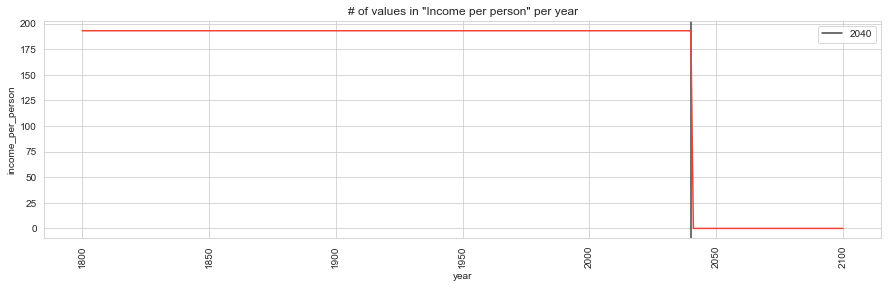

```python
plt.figure(figsize=(15,4))
plt.title('# of values in "Income per person" per year')
plt.xticks(rotation=90)
plt.axvline(x=2040, label='2040', color='#424242')
sns.lineplot(x= df.groupby('year').count().index, y=df.groupby('year').count()['income_per_person'], color='#F44336')
```

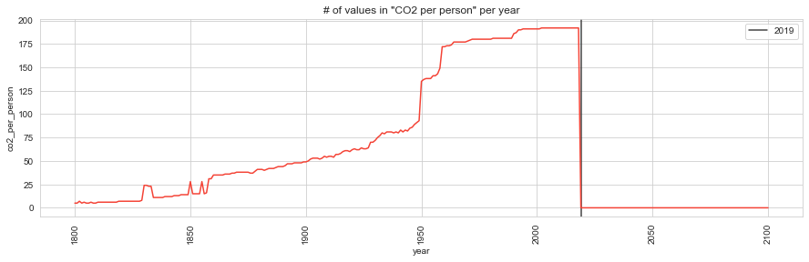

```python
plt.figure(figsize=(15,4))
plt.title('# of values in "CO2 per person" per year')
plt.xticks(rotation=90)
plt.axvline(x=2019, label='2019', color='#424242')
sns.lineplot(x= df.groupby('year').count().index, y=df.groupby('year').count()['co2_per_person'], color='#F44336')
```

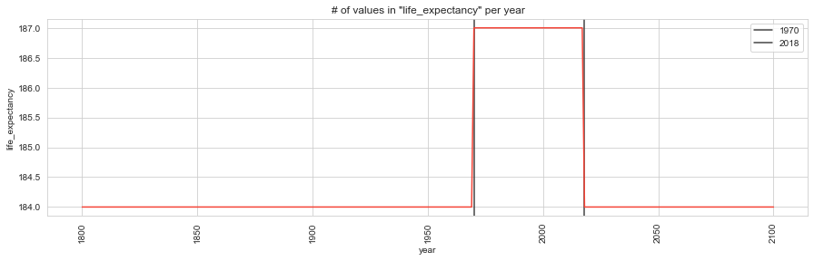

```python
plt.figure(figsize=(15,4))
plt.title('# of values in "life_expectancy" per year')
plt.xticks(rotation=90)
plt.axvline(x=1970, label='1970', color='#424242')
plt.axvline(x=2018, label='2018', color='#424242')
sns.lineplot(x= df.groupby('year').count().index, y=df.groupby('year').count()['life_expectancy'], color='#F44336')
```

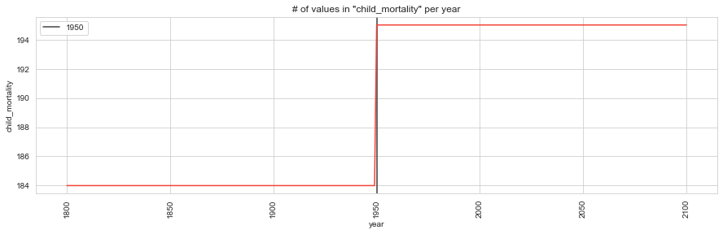

```python
plt.figure(figsize=(15,4))
plt.title('# of values in "child_mortality" per year')
plt.xticks(rotation=90)
plt.axvline(x=1950, label='1950', color='#424242')
sns.lineplot(x= df.groupby('year').count().index, y=df.groupby('year').count()['child_mortality'], color='#F44336')
```

## Removing null values

```python
# based on the temporal distribution of the null values, we will drop the values less than 1968 and more than 2020
df_1970_2018 = df.loc[(df['year']<2019) & (df['year']>1969)]
```

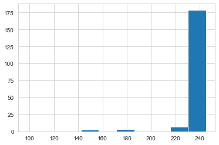

```python
df_1970_2018.groupby('country').count().sum(axis=1).hist()
```

```python
df_1970_2018.groupby('country').count().sum(axis=1).value_counts()
```

```
245    176
244      2
225      2
224      2
147      2
243      1
223      1
222      1
221      1
213      1
196      1
185      1
176      1
174      1
127      1
98       1
dtype: int64
```

```python
df_1970_2018['country'].nunique()
```

```
195
```

```python
country_list = df_1970_2018.groupby('country').count().loc[df_1970_2018.groupby('country').count().sum(axis=1)>244].index
```

```python
len(country_list)
```

```
176
```

```python
df_cleaned = df_1970_2018.loc[df_1970_2018['country'].isin(country_list)]
```

```python
df_cleaned.info()
```

```
<class 'pandas.core.frame.DataFrame'>
Int64Index: 8624 entries, 170 to 46490
Data columns (total 6 columns):
country              8624 non-null object
year                 8624 non-null int32
income_per_person    8624 non-null float64
co2_per_person       8624 non-null float64
life_expectancy      8624 non-null float64
child_mortality      8624 non-null float64
dtypes: float64(4), int32(1), object(1)
memory usage: 437.9+ KB
```

```python
df_cleaned.describe()
```

|  | year | income_per_person | co2_per_person | life_expectancy | child_mortality |
| --- | --- | --- | --- | --- | --- |
| count | 8624.000000 | 8624.000000 | 8624.000000 | 8624.000000 | 8624.000000 |
| mean | 1994.000000 | 13728.471823 | 4.795621 | 66.840740 | 70.197755 |
| std | 14.142956 | 18653.147486 | 7.284590 | 9.549071 | 71.836496 |
| min | 1970.000000 | 312.000000 | 0.004330 | 9.640000 | 1.700000 |
| 25% | 1982.000000 | 2580.000000 | 0.437000 | 60.100000 | 15.800000 |
| 50% | 1994.000000 | 7080.000000 | 2.070000 | 69.300000 | 40.050000 |
| 75% | 2006.000000 | 17500.000000 | 6.740000 | 74.000000 | 106.000000 |
| max | 2018.000000 | 179000.000000 | 87.700000 | 85.000000 | 372.000000 |

```python
df_cleaned.isnull().sum()
```

```
country              0
year                 0
income_per_person    0
co2_per_person       0
life_expectancy      0
child_mortality      0
dtype: int64
```

# Exploratory Data Analysis

## Q1) How have indicators changed in global scale?

Personal income and life expectancy increased from 1970 to 2018. The life expectancy graph shows a linearly increasing trend in that period, however, the graph of the personal income is more fluctuating than the graph of life expectancy.  
Otherwise, CO2 emission and child mortality decreased from 1970 to 2018. The line chart of child mortality shows a linearly decreasing trend in the same period. However, the change of CO2 emission largely fluctuated in that period.  
When I checked the correlation between 'year', 'personal income', 'life expectancy', and 'child mortality', the personal income and life expectancy have a strong and positive correlation with 'year', and the child mortality was strongly and negatively correlated with 'year'.

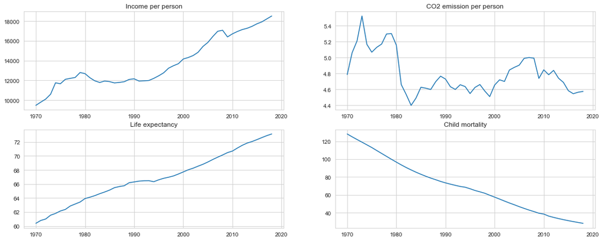

```python
sns.set_style('whitegrid')
plt.figure()
plt.subplots(2,2,figsize=(18,7))
plt.subplot(2,2,1)
plt.title('Income per person')
sns.lineplot(data=df_cleaned.groupby('year').mean()['income_per_person'])
plt.subplot(2,2,2)
plt.title('CO2 emission per person')
sns.lineplot(data=df_cleaned.groupby('year').mean()['co2_per_person'])
plt.subplot(2,2,3)
plt.title('Life expectancy')
sns.lineplot(data=df_cleaned.groupby('year').mean()['life_expectancy'])
plt.subplot(2,2,4)
plt.title('Child mortality')
sns.lineplot(data=df_cleaned.groupby('year').mean()['child_mortality'])
```

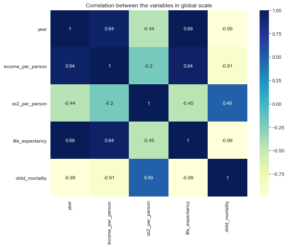

```python
plt.figure(figsize=(9,7))
plt.title('Correlation between the variables in global scale')
sns.heatmap(df_cleaned.groupby('year',as_index=False).mean().corr(), annot=True, cmap='YlGnBu')
```

## How were the other indicators correlated with personal income level?

```python
income_median = df_cleaned['income_per_person'].median()
```

```python
df_high_income = df_cleaned.loc[df_cleaned['income_per_person']>income_median]
df_low_income = df_cleaned.loc[df_cleaned['income_per_person']<=income_median]
```

```python
df_high_income.shape, df_low_income.shape
```

```
((4310, 6), (4314, 6))
```

```python
df_cleaned.corr()
```

|  | year | income_per_person | co2_per_person | life_expectancy | child_mortality |
| --- | --- | --- | --- | --- | --- |
| year | 1.000000 | 0.124133 | -0.014964 | 0.362232 | -0.399235 |
| income_per_person | 0.124133 | 1.000000 | 0.804232 | 0.494927 | -0.426661 |
| co2_per_person | -0.014964 | 0.804232 | 1.000000 | 0.400022 | -0.386765 |
| life_expectancy | 0.362232 | 0.494927 | 0.400022 | 1.000000 | -0.903315 |
| child_mortality | -0.399235 | -0.426661 | -0.386765 | -0.903315 | 1.000000 |

### CO2 Emission (tonnes per person)

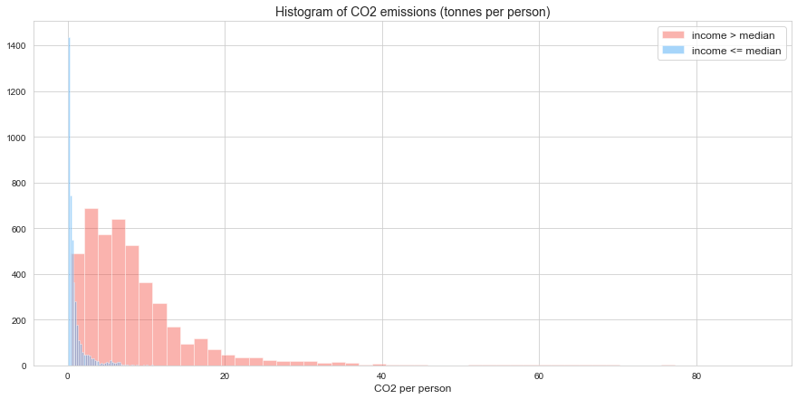

```python
plt.figure(figsize=(15,7))
plt.title('Histogram of CO2 emissions (tonnes per person)', fontsize=14)
sns.distplot(df_high_income['co2_per_person'], color='#F44336', hist=True, kde=False, label='income > median')
sns.distplot(df_low_income['co2_per_person'], color='#2196F3', hist=True, kde=False, label='income <= median')
plt.xlabel('CO2 per person', fontsize=12)
plt.legend(fontsize=12)
```

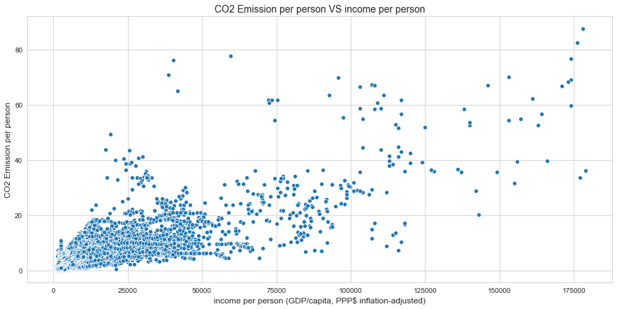

```python
plt.figure(figsize=(15,7))
sns.scatterplot(x=df_cleaned['income_per_person'], y=df_cleaned['co2_per_person'])
plt.xlabel('income per person (GDP/capita, PPP$ inflation-adjusted)',fontsize=12)
plt.ylabel('CO2 Emission per person', fontsize=12)
plt.title('CO2 Emission per person VS income per person', fontsize=14)
```

## Life expectancy

Like CO2 emission, life expectancy in the higher-income group is mostly higher than the lower-income group's life expectancy. However, the correlation between life expectancy and personal income is different by income level. With the group has a personal income of less than 50000, the correlation is positive. However, when we check the group has a personal income of more than 50000, the correlation is negative.

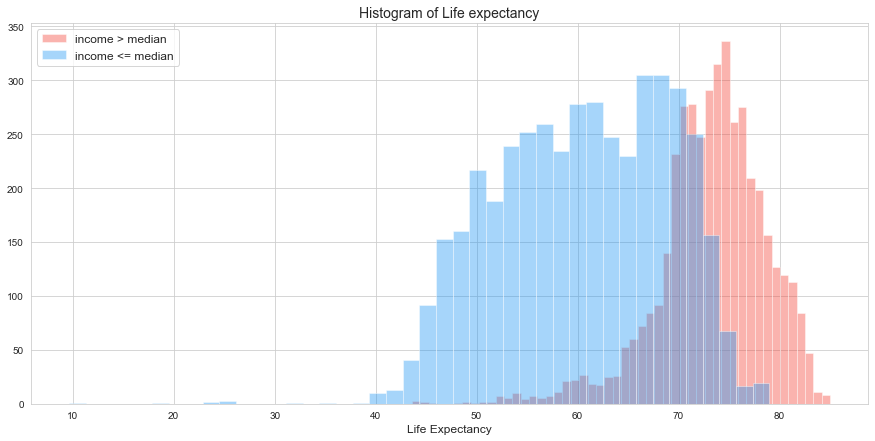

```python
plt.figure(figsize=(15,7))
plt.title('Histogram of Life expectancy', fontsize=14)
sns.distplot(df_high_income['life_expectancy'], color='#F44336', hist=True, kde=False, label='income > median' )
sns.distplot(df_low_income['life_expectancy'], color='#2196F3', hist=True, kde=False, label='income <= median')
plt.xlabel('Life Expectancy', fontsize=12)
plt.legend(fontsize=12)
```

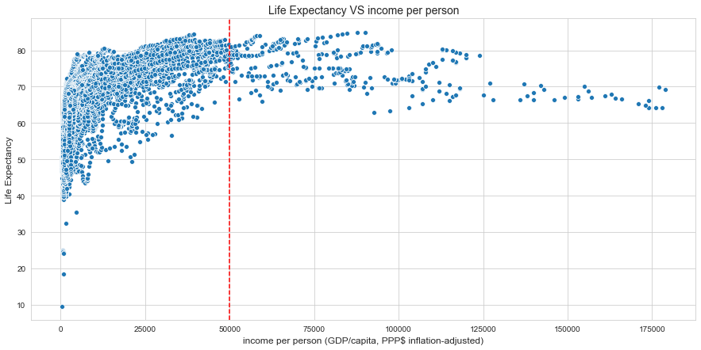

```python
plt.figure(figsize=(15,7))
plt.axvline(x=50000, color='red', linestyle='dashed')
sns.scatterplot(x=df_cleaned['income_per_person'], y=df_cleaned['life_expectancy'])
plt.xlabel('income per person (GDP/capita, PPP$ inflation-adjusted)', fontsize=12)
plt.ylabel('Life Expectancy', fontsize=12)
plt.title('Life Expectancy VS income per person', fontsize=14)
```

## Child Mortality

Unlikely to CO2 emission rate and life expectancy, most of the child mortality of the higher-income group is lower than that of lower-income group. According to below scatter plot, the correlation with child mortality and personal income is negative at the income level of less than 100000, however, in the group has income of more than 100000, the correlation is positive.

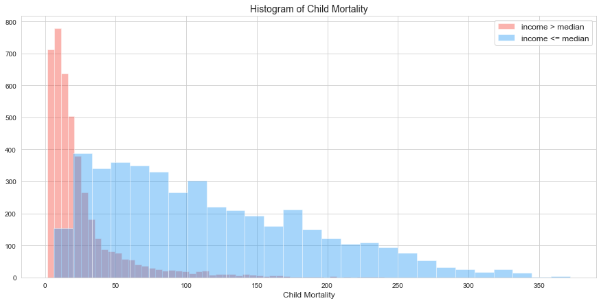

```python
plt.figure(figsize=(15,7))
plt.title('Histogram of Child Mortality', fontsize=14)
sns.distplot(df_high_income['child_mortality'], color='#F44336', hist=True, kde=False, label='income > median')
sns.distplot(df_low_income['child_mortality'], color='#2196F3', hist=True, kde=False, label='income <= median')
plt.xlabel('Child Mortality', fontsize=12)
plt.legend(fontsize=12)
```

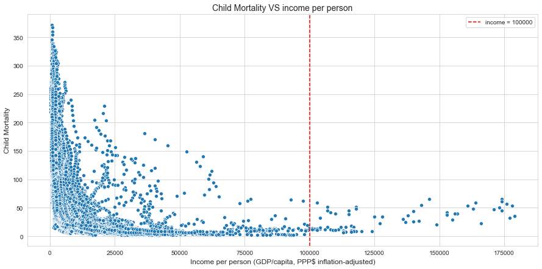

```python
plt.figure(figsize=(15,7))
plt.axvline(x=100000, color='red', linestyle='dashed', label='income = 100000')
sns.scatterplot(x=df_cleaned['income_per_person'], y=df_cleaned['child_mortality'])
plt.xlabel('Income per person (GDP/capita, PPP$ inflation-adjusted)', fontsize=12)
plt.ylabel('Child Mortality', fontsize=12)
plt.title('Child Mortality VS income per person', fontsize=14)
```

# Conclusion

In this project, we reviewed the changes in personal income, CO2 emission, life expectancy, and child mortality of countries per year. From 1970 to 2018, at the global level, we found

- Personal income and life expectancy increased, and CO2 emission and child mortality have decreased.
- Life expectancy and child mortality show linear trends of changes, personal income fluctuated a little bit, and CO2 emission fluctuated in the most.
- Personal income and life expectancy have strong and positive correlations with year, child mortality has strong and negative correlation, and CO2 emission has a moderate and negative correlation with year.